# 2_CVSH: Pop gen

# Preparing for Pop Gen Analyses

There are a lot of experimental fish from CH to NH in here, as well as fish that strayed from MRH to NH and they should be pulled out before pop gen analyses. These fish weren’t actually used as broodstock and will skew results. They will drop out of the pedigree analyses, but not out of analyses using genotypes without PBT. Additionally, some steelhead at MRH were “heldover” at the hatchery to compensate for lower numbers in dry years. These fish should be flagged as well.

Adults that return to CV hatcheries are not necessarily spawned, especially in instances where fish are very visually distinct from typical hatchery broodstock and can confidently be tossed as strays from other programs. Hayley first identified the 2017 straying event of 2 yo steelhead from MRH straying to NH, so we know we will want to remove these as well from the population genetics analyses. We will also flag trios with kids spawning at different hatcheries than their parents.

Should not be included as broodstock in pop gen:

- dead in tank
- eggs thrown out
- NIMBUS SPAWN
- CFH OR NIMBUS UNKNOWN; NIMBUS FISH STARTED DAY
- COLEMAN/NIMBUS EXPERIMENTAL STEELHEAD
- POSSIBLE RESIDENT FISH, NOT USED AS BROODSTOCK
- MORT

### Installing strataG

first: download 2.4.905 tar.gz from here: https://cran.r-project.org/src/contrib/Archive/strataG/

and also rmetasim v.3.1.7 (.tgz OS X El Capitan binaries) from here: http://cran.nexr.com/web/packages/rmetasim/index.html

Skipping the rmetasim step will throw errors from the C++ compiler (error: use of undeclared identifier ‘random_shuffle’)

install these packages: install.packages(c(“ape”,“apex”,“adegenet”, “copula”, “DT”, “genepop”, “Hmisc”,“pegas”, “phangorn”, “rmetasim”, “swfscMisc”))

then go to Tools>Install Packages…> click for .tar.gz files, then install rmetasim, then strataG

Infile format requirements for *strataG*:

- Two-column format (two columns per locus)
- Missing data should be coded as NA
- Indiv ID column and header row are acceptable
- Locus names should have same root & not be duplicated, e.g., Omy_AldA and Omy_AldA_1

```r
library(strataG)
library(tidyverse)
library(dplyr)
library(ggplot2)
```

```r
# metadata and genotypes
pop_met <- read_rds("../metadata/cvsh_meta.rds")
pop_genos <- read_rds("../metadata/cvsh_geno.rds")

# format pop_gen to wide column format
pop_gen1 <- pop_genos %>%
  mutate(locus = case_when(
    gene_copy == 1 ~ paste(locus),
    gene_copy ==2 ~ paste(locus, "_1", sep="")
  )) %>%
  select(-gene_copy) %>%
  pivot_wider(names_from = locus, values_from = allele_int)

# bind year and hatchery from metadata
pop_gen2 <- left_join(pop_met %>% select(indiv, spawner_group, sex, year, hatchery), pop_gen1, by = "indiv")
```

### Adding broodstock column to cvsh

Use sample comments in metadata to flag/remove the following:

- dead in tank
- eggs thrown out
- NIMBUS SPAWN
- CFH OR NIMBUS UNKNOWN; NIMBUS FISH STARTED DAY
- COLEMAN/NIMBUS EXPERIMENTAL STEELHEAD
- POSSIBLE RESIDENT FISH, NOT USED AS BROODSTOCK
- MORT

```r
brood_meta <- pop_met %>%
  mutate(broodstock = case_when(
    grepl("DEAD", SAMPLE_COMMENTS) ~ "no",
    grepl("THROWN", SAMPLE_COMMENTS) ~ "no",
    grepl("MORT", SAMPLE_COMMENTS) ~ "no",
    grepl("NIMBUS SPAWN", SAMPLE_COMMENTS) ~ "no",
    grepl("CFH OR NIMBUS UNKNOWN;", SAMPLE_COMMENTS) ~ "no",
    grepl("EXPERIMENTAL", SAMPLE_COMMENTS) ~ "no",
    grepl("RESIDENT", SAMPLE_COMMENTS) ~ "no",
   TRUE ~ "yes"), .after=hatchery) %>%
  filter(broodstock == "yes")

all_pop <- pop_gen2 %>%
  filter(indiv %in% brood_meta$indiv)
```

After decline in returns during drought, management at MRH “heldover” steelhead at the hatchery without releasing after spawning. These fish have holdover included in sample comments, so good to make a list of ids for reference.

```r
holdovers <- pop_met %>%
  mutate(holdover = case_when(
    grepl("HOLD OVER", SAMPLE_COMMENTS) ~ "holdover",
    !(grepl("HOLD OVER", SAMPLE_COMMENTS)) ~ "no"
  )) %>%
  select(NMFS_DNA_ID, spawner_group:hatchery, SAMPLE_COMMENTS, holdover) %>%
  filter(holdover == "holdover")

write_rds(holdovers, "../metadata/holdovers.rds")
```

Next, use pedigree to create list of 2015 MRH > 2017 NH steelhead - know from hatcheries + H.N.’s analysis that these strays happened from MRH to NH.

We will run analyses with these strays both included or excluded.

included in all_pop excluded in rem_pop

```r
# pedigree - for calculating age and for finding the 2015>2017 strays
ped <- read_rds("../processed_data/CV_pedigree.rds")

# 165 strays
mrh_nh_strays <- ped %>%
  separate_rows(kid_year, sep =",") %>%
  filter(SpawnYear == "2015" & kid_year == "2017" & ma_hatchery == "MRH" & kid_hatchery == "NH")
write_rds(mrh_nh_strays, "../processed_data/MRH2015_NH2017_strays.rds")

rem_pop <- all_pop %>%
  filter(!(indiv %in% mrh_nh_strays$kid))
```

# Creating pop gen datasets

pop gen analyses:

We will be comparing programs with other programs, between programs over study years, as well as within program over study years.

## strays NOT removed:

create groups by program - pop list datasets derived from this:

```r
gen_di_split <- all_pop %>%
  group_by(hatchery, year)
group_name_df <- group_keys(gen_di_split) %>%
  mutate(group_name=str_c(as.character(hatchery),"_",year))
group_name <- group_name_df$group_name %>% sort()
```

grouping by program and year

```r
genos_het <- gen_di_split %>%
  select(-sex,-spawner_group) %>%
  group_by(hatchery, year) %>%
  group_split(.keep = FALSE) %>%
  setNames(group_name)
```

grouping by program

```r
genos_pro <- gen_di_split %>%
  group_by(hatchery) %>%
  group_split() %>%
  setNames(c("CH", "FRH", "MRH", "NH"))
```

## strays REMOVED:

create groups by program - pop list datasets derived from this:

```r
gen_di_splitr <- rem_pop %>%
  group_by(hatchery, year)
group_name_dfr <- group_keys(gen_di_splitr) %>%
  mutate(group_name=str_c(as.character(hatchery),"_",year))
group_namer <- group_name_dfr$group_name %>% sort()
```

grouping by program and year

```r
genos_hetr <- gen_di_splitr %>%
  select(-sex,-spawner_group) %>%
  group_by(hatchery, year) %>%
  group_split(.keep = FALSE) %>%
  setNames(group_namer)
```

grouping by program

```r
genos_pror <- gen_di_splitr %>%
  group_by(hatchery) %>%
  group_split() %>%
  setNames(c("CH", "FRH", "MRH", "NH"))
```

# Expected and observed heterozygosity

### Strays NOT removed

```r
ho.program.mean <- lapply(genos_het, function(x){

  x <- distinct(x)
  x[x == 0 ]<-NA

  gt <- df2gtypes(x, ploidy = 2, strata = NULL, id.col = 1, loc.col = 2)

  Ho.lo <- heterozygosity(gt, by.strata = FALSE, type = "observed")
  #Ho by locus

Ho.stra <- heterozygosity(gt, by.strata = TRUE, type = "observed")
  #Ho by stratum and locus

Ho.mean <- heterozygosity(gt, by.strata = FALSE, type = "observed") %>%
  summarise(mean(obsvd.het)) #mean Ho over all loci
  #  mean(obsvd.het)
})

he.program.mean <- lapply(genos_het, function(x){

  x <- distinct(x)
  x[x == 0 ]<-NA

  gt <- df2gtypes(x, ploidy = 2, strata = NULL, id.col = 1, loc.col = 2)

  Ho.lo <- heterozygosity(gt, by.strata = FALSE, type = "observed")
  #Ho by locus

Ho.stra <- heterozygosity(gt, by.strata = TRUE, type = "observed")
  #Ho by stratum and locus

He.mean <- heterozygosity(gt, by.strata = FALSE, type = "expected") %>%
  summarise(mean(exptd.het)) #mean Ho over all loci
  #  mean(obsvd.het)
})

# pull out mean He from list, convert to data.frame object, then reorganize for plotting
MeanHe <- lapply(he.program.mean, '[[', 1)
he_mean <- data.frame(MeanHe) %>%
  gather()
he_mean <- he_mean %>%
  mutate(SpawnYear = (do.call(rbind, strsplit(he_mean$key, split ="_"))[,2]),
         Hatchery = (do.call(rbind, strsplit(he_mean$key, split ="_"))[,1])) %>%
  rename("MeanHe"="value") %>%
  select(-key)

# pull out mean Ho from list, convert to data.frame object, then reorganize for plotting
MeanHo <- lapply(ho.program.mean, '[[', 1)
ho_mean <- data.frame(MeanHo) %>%
  gather()
ho_mean <- ho_mean %>%
  mutate(SpawnYear = (do.call(rbind, strsplit(ho_mean$key, split ="_"))[,2]),
         Hatchery = (do.call(rbind, strsplit(ho_mean$key, split ="_"))[,1])) %>%
  rename("MeanHo"="value") %>%
  select(-key)

# combine tables
heho <- left_join(he_mean, ho_mean)%>%
  mutate(MeanHoe = (as.numeric(MeanHo)/as.numeric(MeanHe))) %>%
  rename("hatchery"="Hatchery", "year"="SpawnYear")
```

### Strays REMOVED

```r
# combine tables
hehor <- left_join(he_meanr, ho_meanr)%>%
  mutate(MeanHoe = (as.numeric(MeanHo)/as.numeric(MeanHe))) %>%
  rename("hatchery"="Hatchery", "year"="SpawnYear")
```

[output not shown]

# Fst

- by program across year
- by year in program

```r
set.seed(5)

all_pop_sub <- all_pop %>%
  group_by(hatchery, year) %>%
  sample_n(50)

rem_pop_sub <- rem_pop %>%
  group_by(hatchery, year) %>%
  sample_n(50)
```

## Across Programs and Years

Similarity of returning adults programs to each other over time

### Strays NOT removed

```r
# add CH-CH, FRH-FRH, etc for each
fst_ed <- lapply(fst_yr_rs, function(x){
 all <- x %>%
  expand(strata.1, strata.2) %>%
  add_row(strata.1 = "CH", strata.2="CH") %>%
  add_row(strata.1 = "NH", strata.2="NH") %>%
  add_row(strata.1 = "FRH", strata.2="CH") %>%
  add_row(strata.1 = "MRH", strata.2="CH") %>%
  add_row(strata.1 = "NH", strata.2 ="CH") %>%
  add_row(strata.1 = "NH", strata.2 ="FRH") %>%
  add_row(strata.1 = "NH", strata.2 ="MRH") %>%
  mutate(type1 = paste0(strata.1,sep=":",strata.2),
         type2 = paste0(strata.2,sep =":",strata.1)) %>%
  arrange(type1)

 y <- x %>%
  mutate(type1 = paste0(strata.1,sep=":",strata.2),
         type2 = paste0(strata.2,sep =":",strata.1))

fst_file <- left_join(all, y %>% select(type1, Fst, Fst.p.val)) %>%
  left_join(., y %>% select(type2, Fst, Fst.p.val), by=c("type1"="type2")) %>%
  mutate(Fst = coalesce(Fst.x, Fst.y),
         Fst.p.val = coalesce(Fst.p.val.x, Fst.p.val.y)) %>%
  select(strata.1, strata.2, Fst, Fst.p.val) %>%
  mutate(Fst = case_when(
    strata.1 != strata.2 ~ Fst,
    strata.1 == strata.2 ~ 0),
        Fst.p.val = case_when(
    strata.1 != strata.2 ~ Fst.p.val,
    strata.1 == strata.2 ~ 0.000999001))

})
```

[output not shown]

### Strays REMOVED

```r
fst_cvr <- rem_pop_sub %>%
  group_by(year)
group_name_dfr <- group_keys(fst_cvr)
group_namer <- unique(group_name_dfr$year)


# filter by year into groups
fst_rnr <- fst_cvr %>%
  group_by(year) %>%
  group_split() %>%
  setNames(group_namer)


# function to run fst on each year between programs, and extract results
# ploidy is how many alleles
# strata is what strata to compare
# id.col is # id.column
# loc.col is starting # loci columns

fst_yrr <- lapply(fst_rnr, function(x){
   x[x == 0 ]<-NA
  gt <- df2gtypes(x, ploidy = 2, strata = 5, id.col = 1, loc.col = 6)

  fst <- pairwiseTest(gt, stats = "fst")
  fst
})
```

```
<<< gtypes created on 2023-07-12 13:23:09 >>>
 2023-07-12 13:23:09 : Pairwise tests : 1000 permutations
   2023-07-12 13:23:09 : CH v. FRH
   2023-07-12 13:23:14 : CH v. MRH
   2023-07-12 13:23:19 : CH v. NH
   2023-07-12 13:23:23 : FRH v. MRH
   2023-07-12 13:23:28 : FRH v. NH
   2023-07-12 13:23:33 : MRH v. NH

Population structure results:
```

|  | Fst | Fst.p.val |
| --- | --- | --- |
| CH (50) v. FRH (50) | 0.01639689 | 0.000999001 |
| CH (50) v. MRH (50) | 0.02388697 | 0.000999001 |
| CH (50) v. NH (50) | 0.09242350 | 0.000999001 |
| FRH (50) v. MRH (50) | 0.01347521 | 0.000999001 |
| FRH (50) v. NH (50) | 0.09517962 | 0.000999001 |
| MRH (50) v. NH (50) | 0.10381537 | 0.000999001 |

```
<<< gtypes created on 2023-07-12 13:23:37 >>>
 2023-07-12 13:23:38 : Pairwise tests : 1000 permutations
   2023-07-12 13:23:38 : CH v. FRH
   2023-07-12 13:23:43 : CH v. MRH
   2023-07-12 13:23:48 : CH v. NH
   2023-07-12 13:23:52 : FRH v. MRH
   2023-07-12 13:23:57 : FRH v. NH
   2023-07-12 13:24:02 : MRH v. NH

Population structure results:
```

|  | Fst | Fst.p.val |
| --- | --- | --- |
| CH (50) v. FRH (50) | 0.02127170 | 0.000999001 |
| CH (50) v. MRH (50) | 0.03149539 | 0.000999001 |
| CH (50) v. NH (50) | 0.08953728 | 0.000999001 |
| FRH (50) v. MRH (50) | 0.02022655 | 0.000999001 |
| FRH (50) v. NH (50) | 0.09041996 | 0.000999001 |
| MRH (50) v. NH (50) | 0.09279203 | 0.000999001 |

```
<<< gtypes created on 2023-07-12 13:24:06 >>>
 2023-07-12 13:24:06 : Pairwise tests : 1000 permutations
   2023-07-12 13:24:06 : CH v. FRH
   2023-07-12 13:24:11 : CH v. MRH
   2023-07-12 13:24:16 : CH v. NH
   2023-07-12 13:24:20 : FRH v. MRH
   2023-07-12 13:24:25 : FRH v. NH
   2023-07-12 13:24:30 : MRH v. NH

Population structure results:
```

|  | Fst | Fst.p.val |
| --- | --- | --- |
| CH (50) v. FRH (50) | 0.021448082 | 0.000999001 |
| CH (50) v. MRH (50) | 0.028823098 | 0.000999001 |
| CH (50) v. NH (50) | 0.101814633 | 0.000999001 |
| FRH (50) v. MRH (50) | 0.008825059 | 0.000999001 |
| FRH (50) v. NH (50) | 0.098210867 | 0.000999001 |
| MRH (50) v. NH (50) | 0.108332593 | 0.000999001 |

```
<<< gtypes created on 2023-07-12 13:24:34 >>>
 2023-07-12 13:24:34 : Pairwise tests : 1000 permutations
   2023-07-12 13:24:34 : CH v. FRH
   2023-07-12 13:24:39 : CH v. MRH
   2023-07-12 13:24:44 : CH v. NH
   2023-07-12 13:24:49 : FRH v. MRH
   2023-07-12 13:24:54 : FRH v. NH
   2023-07-12 13:24:59 : MRH v. NH

Population structure results:
```

|  | Fst | Fst.p.val |
| --- | --- | --- |
| CH (50) v. FRH (50) | 0.01891591 | 0.000999001 |
| CH (50) v. MRH (50) | 0.02464697 | 0.000999001 |
| CH (50) v. NH (50) | 0.09843986 | 0.000999001 |
| FRH (50) v. MRH (50) | 0.01969066 | 0.000999001 |
| FRH (50) v. NH (50) | 0.09702613 | 0.000999001 |
| MRH (50) v. NH (50) | 0.09885546 | 0.000999001 |

```
<<< gtypes created on 2023-07-12 13:25:04 >>>
 2023-07-12 13:25:04 : Pairwise tests : 1000 permutations
   2023-07-12 13:25:04 : CH v. FRH
   2023-07-12 13:25:08 : CH v. MRH
   2023-07-12 13:25:13 : CH v. NH
   2023-07-12 13:25:18 : FRH v. MRH
   2023-07-12 13:25:22 : FRH v. NH
   2023-07-12 13:25:27 : MRH v. NH

Population structure results:
```

|  | Fst | Fst.p.val |
| --- | --- | --- |
| CH (50) v. FRH (50) | 0.02069696 | 0.000999001 |
| CH (50) v. MRH (50) | 0.03043930 | 0.000999001 |
| CH (50) v. NH (50) | 0.10068952 | 0.000999001 |
| FRH (50) v. MRH (50) | 0.01815747 | 0.000999001 |
| FRH (50) v. NH (50) | 0.09819628 | 0.000999001 |
| MRH (50) v. NH (50) | 0.11034626 | 0.000999001 |

```
<<< gtypes created on 2023-07-12 13:25:32 >>>
 2023-07-12 13:25:32 : Pairwise tests : 1000 permutations
   2023-07-12 13:25:32 : CH v. FRH
   2023-07-12 13:25:36 : CH v. MRH
   2023-07-12 13:25:41 : CH v. NH
   2023-07-12 13:25:45 : FRH v. MRH
   2023-07-12 13:25:50 : FRH v. NH
   2023-07-12 13:25:55 : MRH v. NH

Population structure results:
```

|  | Fst | Fst.p.val |
| --- | --- | --- |
| CH (50) v. FRH (50) | 0.01687534 | 0.000999001 |
| CH (50) v. MRH (50) | 0.05237332 | 0.000999001 |
| CH (50) v. NH (50) | 0.11681378 | 0.000999001 |
| FRH (50) v. MRH (50) | 0.03157471 | 0.000999001 |
| FRH (50) v. NH (50) | 0.11200817 | 0.000999001 |
| MRH (50) v. NH (50) | 0.13429427 | 0.000999001 |

```
<<< gtypes created on 2023-07-12 13:25:59 >>>
 2023-07-12 13:25:59 : Pairwise tests : 1000 permutations
   2023-07-12 13:25:59 : CH v. FRH
   2023-07-12 13:26:04 : CH v. MRH
   2023-07-12 13:26:08 : CH v. NH
   2023-07-12 13:26:13 : FRH v. MRH
   2023-07-12 13:26:17 : FRH v. NH
   2023-07-12 13:26:22 : MRH v. NH

Population structure results:
```

|  | Fst | Fst.p.val |
| --- | --- | --- |
| CH (50) v. FRH (50) | 0.02218105 | 0.000999001 |
| CH (50) v. MRH (50) | 0.03356364 | 0.000999001 |
| CH (50) v. NH (50) | 0.07450322 | 0.000999001 |
| FRH (50) v. MRH (50) | 0.01969057 | 0.000999001 |
| FRH (50) v. NH (50) | 0.06671633 | 0.000999001 |
| MRH (50) v. NH (50) | 0.06343252 | 0.000999001 |

```
<<< gtypes created on 2023-07-12 13:26:27 >>>
 2023-07-12 13:26:27 : Pairwise tests : 1000 permutations
   2023-07-12 13:26:27 : CH v. FRH
   2023-07-12 13:26:31 : CH v. MRH
   2023-07-12 13:26:36 : CH v. NH
   2023-07-12 13:26:40 : FRH v. MRH
   2023-07-12 13:26:45 : FRH v. NH
   2023-07-12 13:26:49 : MRH v. NH

Population structure results:
```

|  | Fst | Fst.p.val |
| --- | --- | --- |
| CH (50) v. FRH (50) | 0.02104384 | 0.000999001 |
| CH (50) v. MRH (50) | 0.04022338 | 0.000999001 |
| CH (50) v. NH (50) | 0.11327137 | 0.000999001 |
| FRH (50) v. MRH (50) | 0.02249433 | 0.000999001 |
| FRH (50) v. NH (50) | 0.09738616 | 0.000999001 |
| MRH (50) v. NH (50) | 0.10988896 | 0.000999001 |

```
<<< gtypes created on 2023-07-12 13:26:54 >>>
 2023-07-12 13:26:54 : Pairwise tests : 1000 permutations
   2023-07-12 13:26:54 : CH v. FRH
   2023-07-12 13:26:58 : CH v. MRH
   2023-07-12 13:27:03 : CH v. NH
   2023-07-12 13:27:07 : FRH v. MRH
   2023-07-12 13:27:12 : FRH v. NH
   2023-07-12 13:27:17 : MRH v. NH

Population structure results:
```

|  | Fst | Fst.p.val |
| --- | --- | --- |
| CH (50) v. FRH (50) | 0.01679591 | 0.000999001 |
| CH (50) v. MRH (50) | 0.03121302 | 0.000999001 |
| CH (50) v. NH (50) | 0.11530806 | 0.000999001 |
| FRH (50) v. MRH (50) | 0.01924361 | 0.000999001 |
| FRH (50) v. NH (50) | 0.10560045 | 0.000999001 |
| MRH (50) v. NH (50) | 0.11371869 | 0.000999001 |

```r
fst_resr <- fst_yrr %>%
  setNames(group_namer)

fst_yr_rsr <- lapply(fst_resr, '[[', 1)

# add CH-CH, FRH-FRH, etc for each
fst_edr <- lapply(fst_yr_rsr, function(x){
 all <- x %>%
  expand(strata.1, strata.2) %>%
  add_row(strata.1 = "CH", strata.2="CH") %>%
  add_row(strata.1 = "NH", strata.2="NH") %>%
  add_row(strata.1 = "FRH", strata.2="CH") %>%
  add_row(strata.1 = "MRH", strata.2="CH") %>%
  add_row(strata.1 = "NH", strata.2 ="CH") %>%
  add_row(strata.1 = "NH", strata.2 ="FRH") %>%
  add_row(strata.1 = "NH", strata.2 ="MRH") %>%
  mutate(type1 = paste0(strata.1,sep=":",strata.2),
         type2 = paste0(strata.2,sep =":",strata.1)) %>%
  arrange(type1)

 y <- x %>%
  mutate(type1 = paste0(strata.1,sep=":",strata.2),
         type2 = paste0(strata.2,sep =":",strata.1))

fst_file <- left_join(all, y %>% select(type1, Fst, Fst.p.val)) %>%
  left_join(., y %>% select(type2, Fst, Fst.p.val), by=c("type1"="type2")) %>%
  mutate(Fst = coalesce(Fst.x, Fst.y),
         Fst.p.val = coalesce(Fst.p.val.x, Fst.p.val.y)) %>%
  select(strata.1, strata.2, Fst, Fst.p.val) %>%
  mutate(Fst = case_when(
    strata.1 != strata.2 ~ Fst,
    strata.1 == strata.2 ~ 0),
        Fst.p.val = case_when(
    strata.1 != strata.2 ~ Fst.p.val,
    strata.1 == strata.2 ~ 0.000999001))

})
fst_edr <- Map(cbind, fst_edr, year = names(fst_edr))


fst_results.fr <- do.call(rbind.data.frame, fst_edr)
write_csv(fst_results.fr, "../tables/S2_fst_b_pro_rem.csv")
```

#### Figure

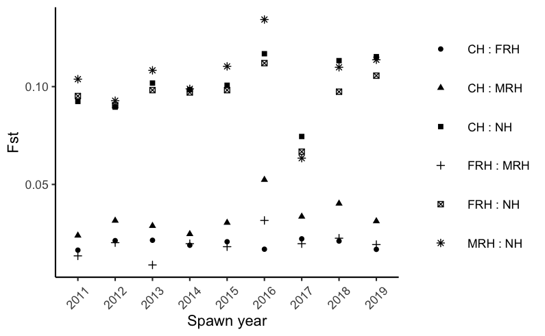

```r
fst_plot <- fst_results.fr %>%
  mutate(plot_a = paste(year,"_",strata.1),
         plot_b = paste(year,"_",strata.2),
         plot_c = paste(strata.1,":",strata.2))

fsty_plot <- fst_plot %>%
  mutate(kp = case_when(
    plot_c == "NH : CH" | plot_c == "NH : FRH" | plot_c == "NH : MRH" | plot_c == "MRH : FRH" | plot_c == "MRH : CH" | plot_c == "FRH : CH"
    ~ "rm",
    plot_c != "NH : CH" | plot_c != "NH : FRH" | plot_c != "NH : MRH" | plot_c != "MRH : FRH" | plot_c != "MRH : CH" | plot_c != "FRH : CH"
    ~ "kp")) %>%
  filter(kp != "rm") %>%
  filter(Fst > 0)

fsty_gg <- ggplot(fsty_plot)+
  geom_point(aes(x=as.factor(year),y=Fst,shape=plot_c, fill= plot_c))+
  theme_classic()+
  theme(axis.text.x = element_text(angle = 45, vjust = 0.5))+
  labs(x = "Spawn year", y= "Fst")+
  guides(color = guide_legend(override.aes = list(size = 10) ) )+
  theme(legend.title = element_blank(), legend.key.size = unit(1, 'cm'))

fsty_gg
```

```r
ggsave(plot = fsty_gg, file = "../figures/S5_fstb.png",
       width = 15, height = 10, units = "cm", dpi = 800)
```

## Within Program Years

How effectively are respective broodstock programs managed?

### Strays NOT removed

```r
fst_pr <- all_pop_sub %>%
  group_by(hatchery)
group_name_df <- group_keys(fst_pr)
group_name <- unique(group_name_df$hatchery)


# filter by hatchery into groups
fst_prog <- fst_pr %>%
  group_by(hatchery) %>%
  group_split() %>%
  setNames(group_name)

fst_yr <- lapply(fst_prog, function(x){

  gt <- df2gtypes(x, ploidy = 2, strata = 4, id.col = 1, loc.col = 6)

  fst <- pairwiseTest(gt, stats = "fst")
  fst
})
```

```
<<< gtypes created on 2023-07-12 13:50:03 >>>
 2023-07-12 13:50:04 : Pairwise tests : 1000 permutations
   2023-07-12 13:50:04 : 2011 v. 2012
   2023-07-12 13:50:09 : 2011 v. 2013
   2023-07-12 13:50:14 : 2011 v. 2014
```

```
   2023-07-12 13:50:20 : 2011 v. 2015
   2023-07-12 13:50:25 : 2011 v. 2016
   2023-07-12 13:50:30 : 2011 v. 2017
   2023-07-12 13:50:35 : 2011 v. 2018
   2023-07-12 13:50:40 : 2011 v. 2019
   2023-07-12 13:50:45 : 2012 v. 2013
   2023-07-12 13:50:50 : 2012 v. 2014
```

```
   2023-07-12 13:50:56 : 2012 v. 2015
   2023-07-12 13:51:01 : 2012 v. 2016
   2023-07-12 13:51:06 : 2012 v. 2017
   2023-07-12 13:51:11 : 2012 v. 2018
   2023-07-12 13:51:16 : 2012 v. 2019
   2023-07-12 13:51:21 : 2013 v. 2014
   2023-07-12 13:51:26 : 2013 v. 2015
   2023-07-12 13:51:30 : 2013 v. 2016
   2023-07-12 13:51:35 : 2013 v. 2017
   2023-07-12 13:51:40 : 2013 v. 2018
   2023-07-12 13:51:44 : 2013 v. 2019
   2023-07-12 13:51:49 : 2014 v. 2015
   2023-07-12 13:51:54 : 2014 v. 2016
   2023-07-12 13:51:59 : 2014 v. 2017
   2023-07-12 13:52:04 : 2014 v. 2018
   2023-07-12 13:52:08 : 2014 v. 2019
   2023-07-12 13:52:13 : 2015 v. 2016
   2023-07-12 13:52:18 : 2015 v. 2017
   2023-07-12 13:52:23 : 2015 v. 2018
   2023-07-12 13:52:27 : 2015 v. 2019
   2023-07-12 13:52:32 : 2016 v. 2017
   2023-07-12 13:52:36 : 2016 v. 2018
   2023-07-12 13:52:41 : 2016 v. 2019
   2023-07-12 13:52:46 : 2017 v. 2018
   2023-07-12 13:52:51 : 2017 v. 2019
   2023-07-12 13:52:55 : 2018 v. 2019

Population structure results:
```

|  | Fst | Fst.p.val |
| --- | --- | --- |
| 2011 (50) v. 2012 (50) | -1.071363e-04 | 0.47552448 |
| 2011 (50) v. 2013 (50) | 1.391989e-03 | 0.21278721 |
| 2011 (50) v. 2014 (50) | 1.037107e-05 | 0.44355644 |
| 2011 (50) v. 2015 (50) | 1.301259e-03 | 0.22577423 |
| 2011 (50) v. 2016 (50) | -5.597167e-04 | 0.60939061 |
| 2011 (50) v. 2017 (50) | 1.236078e-03 | 0.24075924 |
| 2011 (50) v. 2018 (50) | 2.702801e-03 | 0.06693307 |
| 2011 (50) v. 2019 (50) | -5.144262e-04 | 0.59840160 |
| 2012 (50) v. 2013 (50) | 6.024895e-04 | 0.33966034 |
| 2012 (50) v. 2014 (50) | -8.306445e-04 | 0.66133866 |

[output cut: 26 more lines]

```
<<< gtypes created on 2023-07-12 13:53:00 >>>
 2023-07-12 13:53:00 : Pairwise tests : 1000 permutations
   2023-07-12 13:53:00 : 2011 v. 2012
   2023-07-12 13:53:06 : 2011 v. 2013
   2023-07-12 13:53:10 : 2011 v. 2014
   2023-07-12 13:53:15 : 2011 v. 2015
```

```
   2023-07-12 13:53:20 : 2011 v. 2016
   2023-07-12 13:53:25 : 2011 v. 2017
   2023-07-12 13:53:30 : 2011 v. 2018
   2023-07-12 13:53:35 : 2011 v. 2019
   2023-07-12 13:53:40 : 2012 v. 2013
   2023-07-12 13:53:44 : 2012 v. 2014
   2023-07-12 13:53:49 : 2012 v. 2015
   2023-07-12 13:53:55 : 2012 v. 2016
   2023-07-12 13:53:59 : 2012 v. 2017
   2023-07-12 13:54:04 : 2012 v. 2018
   2023-07-12 13:54:09 : 2012 v. 2019
   2023-07-12 13:54:13 : 2013 v. 2014
   2023-07-12 13:54:19 : 2013 v. 2015
   2023-07-12 13:54:23 : 2013 v. 2016
   2023-07-12 13:54:28 : 2013 v. 2017
   2023-07-12 13:54:33 : 2013 v. 2018
   2023-07-12 13:54:37 : 2013 v. 2019
   2023-07-12 13:54:42 : 2014 v. 2015
   2023-07-12 13:54:47 : 2014 v. 2016
   2023-07-12 13:54:52 : 2014 v. 2017
   2023-07-12 13:54:57 : 2014 v. 2018
   2023-07-12 13:55:01 : 2014 v. 2019
   2023-07-12 13:55:06 : 2015 v. 2016
   2023-07-12 13:55:11 : 2015 v. 2017
   2023-07-12 13:55:15 : 2015 v. 2018
   2023-07-12 13:55:20 : 2015 v. 2019
   2023-07-12 13:55:24 : 2016 v. 2017
   2023-07-12 13:55:29 : 2016 v. 2018
   2023-07-12 13:55:34 : 2016 v. 2019
   2023-07-12 13:55:38 : 2017 v. 2018
   2023-07-12 13:55:43 : 2017 v. 2019
   2023-07-12 13:55:48 : 2018 v. 2019

Population structure results:
```

|  | Fst | Fst.p.val |
| --- | --- | --- |
| 2011 (50) v. 2012 (50) | 8.081850e-03 | 0.000999001 |
| 2011 (50) v. 2013 (50) | 2.082350e-03 | 0.134865135 |
| 2011 (50) v. 2014 (50) | 2.173594e-03 | 0.094905095 |
| 2011 (50) v. 2015 (50) | 1.942058e-03 | 0.118881119 |
| 2011 (50) v. 2016 (50) | 9.463455e-04 | 0.266733267 |
| 2011 (50) v. 2017 (50) | 1.892050e-03 | 0.136863137 |
| 2011 (50) v. 2018 (50) | 2.279958e-03 | 0.105894106 |
| 2011 (50) v. 2019 (50) | -1.445746e-03 | 0.797202797 |
| 2012 (50) v. 2013 (50) | 7.336173e-03 | 0.001998002 |
| 2012 (50) v. 2014 (50) | 3.380797e-03 | 0.040959041 |

[output cut: 26 more lines]

```
<<< gtypes created on 2023-07-12 13:55:52 >>>
 2023-07-12 13:55:52 : Pairwise tests : 1000 permutations
   2023-07-12 13:55:52 : 2011 v. 2012
   2023-07-12 13:55:57 : 2011 v. 2013
   2023-07-12 13:56:01 : 2011 v. 2014
   2023-07-12 13:56:06 : 2011 v. 2015
   2023-07-12 13:56:11 : 2011 v. 2016
   2023-07-12 13:56:15 : 2011 v. 2017
   2023-07-12 13:56:20 : 2011 v. 2018
   2023-07-12 13:56:24 : 2011 v. 2019
   2023-07-12 13:56:29 : 2012 v. 2013
   2023-07-12 13:56:33 : 2012 v. 2014
   2023-07-12 13:56:38 : 2012 v. 2015
   2023-07-12 13:56:43 : 2012 v. 2016
   2023-07-12 13:56:47 : 2012 v. 2017
   2023-07-12 13:56:52 : 2012 v. 2018
   2023-07-12 13:56:56 : 2012 v. 2019
   2023-07-12 13:57:01 : 2013 v. 2014
   2023-07-12 13:57:06 : 2013 v. 2015
   2023-07-12 13:57:10 : 2013 v. 2016
   2023-07-12 13:57:15 : 2013 v. 2017
   2023-07-12 13:57:19 : 2013 v. 2018
   2023-07-12 13:57:24 : 2013 v. 2019
   2023-07-12 13:57:28 : 2014 v. 2015
   2023-07-12 13:57:33 : 2014 v. 2016
   2023-07-12 13:57:38 : 2014 v. 2017
   2023-07-12 13:57:42 : 2014 v. 2018
   2023-07-12 13:57:47 : 2014 v. 2019
   2023-07-12 13:57:51 : 2015 v. 2016
   2023-07-12 13:57:56 : 2015 v. 2017
   2023-07-12 13:58:00 : 2015 v. 2018
   2023-07-12 13:58:05 : 2015 v. 2019
   2023-07-12 13:58:10 : 2016 v. 2017
   2023-07-12 13:58:14 : 2016 v. 2018
   2023-07-12 13:58:19 : 2016 v. 2019
   2023-07-12 13:58:23 : 2017 v. 2018
   2023-07-12 13:58:28 : 2017 v. 2019
   2023-07-12 13:58:33 : 2018 v. 2019

Population structure results:
```

|  | Fst | Fst.p.val |
| --- | --- | --- |
| 2011 (50) v. 2012 (50) | 0.018408730 | 0.000999001 |
| 2011 (50) v. 2013 (50) | 0.008817165 | 0.001998002 |
| 2011 (50) v. 2014 (50) | 0.013849776 | 0.000999001 |
| 2011 (50) v. 2015 (50) | 0.016497259 | 0.000999001 |
| 2011 (50) v. 2016 (50) | 0.035983968 | 0.000999001 |
| 2011 (50) v. 2017 (50) | 0.022038067 | 0.000999001 |
| 2011 (50) v. 2018 (50) | 0.032658122 | 0.000999001 |
| 2011 (50) v. 2019 (50) | 0.023388907 | 0.000999001 |
| 2012 (50) v. 2013 (50) | 0.013593220 | 0.000999001 |
| 2012 (50) v. 2014 (50) | 0.002785147 | 0.083916084 |

[output cut: 26 more lines]

```
<<< gtypes created on 2023-07-12 13:58:37 >>>
 2023-07-12 13:58:38 : Pairwise tests : 1000 permutations
   2023-07-12 13:58:38 : 2011 v. 2012
   2023-07-12 13:58:42 : 2011 v. 2013
   2023-07-12 13:58:47 : 2011 v. 2014
   2023-07-12 13:58:51 : 2011 v. 2015
   2023-07-12 13:58:56 : 2011 v. 2016
   2023-07-12 13:59:01 : 2011 v. 2017
   2023-07-12 13:59:05 : 2011 v. 2018
   2023-07-12 13:59:10 : 2011 v. 2019
   2023-07-12 13:59:15 : 2012 v. 2013
   2023-07-12 13:59:19 : 2012 v. 2014
   2023-07-12 13:59:24 : 2012 v. 2015
   2023-07-12 13:59:28 : 2012 v. 2016
   2023-07-12 13:59:33 : 2012 v. 2017
   2023-07-12 13:59:37 : 2012 v. 2018
   2023-07-12 13:59:42 : 2012 v. 2019
   2023-07-12 13:59:47 : 2013 v. 2014
   2023-07-12 13:59:51 : 2013 v. 2015
   2023-07-12 13:59:56 : 2013 v. 2016
   2023-07-12 14:00:01 : 2013 v. 2017
   2023-07-12 14:00:05 : 2013 v. 2018
   2023-07-12 14:00:10 : 2013 v. 2019
   2023-07-12 14:00:14 : 2014 v. 2015
   2023-07-12 14:00:19 : 2014 v. 2016
   2023-07-12 14:00:23 : 2014 v. 2017
   2023-07-12 14:00:28 : 2014 v. 2018
   2023-07-12 14:00:32 : 2014 v. 2019
   2023-07-12 14:00:37 : 2015 v. 2016
   2023-07-12 14:00:41 : 2015 v. 2017
   2023-07-12 14:00:46 : 2015 v. 2018
   2023-07-12 14:00:51 : 2015 v. 2019
   2023-07-12 14:00:55 : 2016 v. 2017
   2023-07-12 14:01:00 : 2016 v. 2018
   2023-07-12 14:01:05 : 2016 v. 2019
   2023-07-12 14:01:09 : 2017 v. 2018
   2023-07-12 14:01:14 : 2017 v. 2019
   2023-07-12 14:01:18 : 2018 v. 2019

Population structure results:
```

|  | Fst | Fst.p.val |
| --- | --- | --- |
| 2011 (50) v. 2012 (50) | 9.071821e-03 | 0.000999001 |
| 2011 (50) v. 2013 (50) | 7.898941e-03 | 0.000999001 |
| 2011 (50) v. 2014 (50) | 5.860837e-05 | 0.469530470 |
| 2011 (50) v. 2015 (50) | 6.452066e-03 | 0.000999001 |
| 2011 (50) v. 2016 (50) | 8.355372e-03 | 0.000999001 |
| 2011 (50) v. 2017 (50) | 2.157859e-02 | 0.000999001 |
| 2011 (50) v. 2018 (50) | 1.763415e-02 | 0.000999001 |
| 2011 (50) v. 2019 (50) | 1.260674e-02 | 0.000999001 |
| 2012 (50) v. 2013 (50) | 9.896761e-03 | 0.000999001 |
| 2012 (50) v. 2014 (50) | 9.867808e-03 | 0.000999001 |

[output cut: 26 more lines]

```r
fst_res <- fst_yr %>%
  setNames(group_name)

fst_b <- lapply(fst_res, '[[', 1) %>%
  setNames(c("CH","FRH","MRH","NH"))
fst_data <- data.frame(fst_b)

fst_keep <- fst_data %>%
  group_by(CH.strata.1) %>%
  arrange(CH.strata.1) %>%
  filter(row_number()==1) %>%
  select(-FRH.strata.1, -FRH.strata.2, -MRH.strata.1,
         -MRH.strata.2, -NH.strata.1, -NH.strata.2) %>%
  rename("SpawnYear1"="CH.strata.1",
         "SpawnYear2"="CH.strata.2")

fst_keep <- fst_keep %>%
  mutate(SpawnYears = paste(SpawnYear1, SpawnYear2, sep=":"))


# great now pull out Fst for each program during each SpawnYear
fst_ch <- fst_keep %>%
  select(SpawnYears, CH.Fst) %>%
  mutate(Hatchery = "CH") %>%
  rename("Mean_Fst"="CH.Fst")
fst_frh <- fst_keep %>%
  select(SpawnYears, FRH.Fst) %>%
  mutate(Hatchery = "FRH") %>%
  rename("Mean_Fst"="FRH.Fst")
fst_mrh <- fst_keep %>%
  select(SpawnYears, MRH.Fst) %>%
  mutate(Hatchery = "MRH") %>%
  rename("Mean_Fst"="MRH.Fst")
fst_nh <- fst_keep %>%
  select(SpawnYears, NH.Fst) %>%
  mutate(Hatchery = "NH") %>%
  rename("Mean_Fst"="NH.Fst")
fst_mean <- rbind(fst_ch, fst_frh, fst_mrh, fst_nh)
write_csv(fst_mean, "../tables/S3_fst_w_pro.csv")
```

### Strays REMOVED

```r
fst_prr <- rem_pop_sub %>%
  group_by(hatchery)
group_name_dfr <- group_keys(fst_prr)
group_namer <- unique(group_name_dfr$hatchery)


# filter by hatchery into groups
fst_progr <- fst_prr %>%
  group_by(hatchery) %>%
  group_split() %>%
  setNames(group_namer)

fst_yrr <- lapply(fst_progr, function(x){

  gt <- df2gtypes(x, ploidy = 2, strata = 4, id.col = 1, loc.col = 6)

  fst <- pairwiseTest(gt, stats = "fst")
  fst
})
```

```
<<< gtypes created on 2023-07-12 14:07:30 >>>
 2023-07-12 14:07:30 : Pairwise tests : 1000 permutations
   2023-07-12 14:07:30 : 2011 v. 2012
   2023-07-12 14:07:36 : 2011 v. 2013
   2023-07-12 14:07:41 : 2011 v. 2014
   2023-07-12 14:07:45 : 2011 v. 2015
   2023-07-12 14:07:50 : 2011 v. 2016
   2023-07-12 14:07:55 : 2011 v. 2017
   2023-07-12 14:07:59 : 2011 v. 2018
   2023-07-12 14:08:04 : 2011 v. 2019
   2023-07-12 14:08:08 : 2012 v. 2013
   2023-07-12 14:08:13 : 2012 v. 2014
   2023-07-12 14:08:17 : 2012 v. 2015
   2023-07-12 14:08:22 : 2012 v. 2016
   2023-07-12 14:08:27 : 2012 v. 2017
   2023-07-12 14:08:31 : 2012 v. 2018
   2023-07-12 14:08:36 : 2012 v. 2019
   2023-07-12 14:08:40 : 2013 v. 2014
   2023-07-12 14:08:45 : 2013 v. 2015
   2023-07-12 14:08:50 : 2013 v. 2016
   2023-07-12 14:08:54 : 2013 v. 2017
   2023-07-12 14:08:59 : 2013 v. 2018
   2023-07-12 14:09:03 : 2013 v. 2019
   2023-07-12 14:09:08 : 2014 v. 2015
   2023-07-12 14:09:13 : 2014 v. 2016
   2023-07-12 14:09:17 : 2014 v. 2017
   2023-07-12 14:09:22 : 2014 v. 2018
   2023-07-12 14:09:26 : 2014 v. 2019
   2023-07-12 14:09:31 : 2015 v. 2016
   2023-07-12 14:09:35 : 2015 v. 2017
   2023-07-12 14:09:40 : 2015 v. 2018
   2023-07-12 14:09:44 : 2015 v. 2019
   2023-07-12 14:09:49 : 2016 v. 2017
   2023-07-12 14:09:53 : 2016 v. 2018
   2023-07-12 14:09:58 : 2016 v. 2019
   2023-07-12 14:10:03 : 2017 v. 2018
   2023-07-12 14:10:07 : 2017 v. 2019
   2023-07-12 14:10:12 : 2018 v. 2019

Population structure results:
```

|  | Fst | Fst.p.val |
| --- | --- | --- |
| 2011 (50) v. 2012 (50) | 2.588325e-03 | 0.063936064 |
| 2011 (50) v. 2013 (50) | -1.319638e-03 | 0.802197802 |
| 2011 (50) v. 2014 (50) | 7.745515e-04 | 0.305694306 |
| 2011 (50) v. 2015 (50) | -1.592953e-03 | 0.843156843 |
| 2011 (50) v. 2016 (50) | 4.005049e-04 | 0.388611389 |
| 2011 (50) v. 2017 (50) | 1.297443e-03 | 0.219780220 |
| 2011 (50) v. 2018 (50) | -4.914224e-05 | 0.444555445 |
| 2011 (50) v. 2019 (50) | 9.259848e-04 | 0.279720280 |
| 2012 (50) v. 2013 (50) | 1.131528e-03 | 0.243756244 |
| 2012 (50) v. 2014 (50) | -9.624857e-04 | 0.701298701 |

[output cut: 26 more lines]

```
<<< gtypes created on 2023-07-12 14:10:16 >>>
 2023-07-12 14:10:17 : Pairwise tests : 1000 permutations
   2023-07-12 14:10:17 : 2011 v. 2012
   2023-07-12 14:10:21 : 2011 v. 2013
   2023-07-12 14:10:26 : 2011 v. 2014
   2023-07-12 14:10:30 : 2011 v. 2015
   2023-07-12 14:10:35 : 2011 v. 2016
   2023-07-12 14:10:39 : 2011 v. 2017
   2023-07-12 14:10:44 : 2011 v. 2018
   2023-07-12 14:10:49 : 2011 v. 2019
   2023-07-12 14:10:53 : 2012 v. 2013
   2023-07-12 14:10:58 : 2012 v. 2014
   2023-07-12 14:11:02 : 2012 v. 2015
   2023-07-12 14:11:07 : 2012 v. 2016
   2023-07-12 14:11:12 : 2012 v. 2017
   2023-07-12 14:11:16 : 2012 v. 2018
   2023-07-12 14:11:21 : 2012 v. 2019
   2023-07-12 14:11:25 : 2013 v. 2014
   2023-07-12 14:11:30 : 2013 v. 2015
   2023-07-12 14:11:35 : 2013 v. 2016
   2023-07-12 14:11:39 : 2013 v. 2017
   2023-07-12 14:11:44 : 2013 v. 2018
   2023-07-12 14:11:48 : 2013 v. 2019
   2023-07-12 14:11:53 : 2014 v. 2015
   2023-07-12 14:11:57 : 2014 v. 2016
   2023-07-12 14:12:02 : 2014 v. 2017
   2023-07-12 14:12:07 : 2014 v. 2018
   2023-07-12 14:12:11 : 2014 v. 2019
   2023-07-12 14:12:16 : 2015 v. 2016
   2023-07-12 14:12:20 : 2015 v. 2017
   2023-07-12 14:12:25 : 2015 v. 2018
   2023-07-12 14:12:29 : 2015 v. 2019
   2023-07-12 14:12:34 : 2016 v. 2017
   2023-07-12 14:12:39 : 2016 v. 2018
   2023-07-12 14:12:43 : 2016 v. 2019
   2023-07-12 14:12:48 : 2017 v. 2018
   2023-07-12 14:12:52 : 2017 v. 2019
   2023-07-12 14:12:57 : 2018 v. 2019

Population structure results:
```

|  | Fst | Fst.p.val |
| --- | --- | --- |
| 2011 (50) v. 2012 (50) | 0.0059497342 | 0.004995005 |
| 2011 (50) v. 2013 (50) | 0.0034796369 | 0.027972028 |
| 2011 (50) v. 2014 (50) | 0.0036162157 | 0.015984016 |
| 2011 (50) v. 2015 (50) | 0.0018555500 | 0.144855145 |
| 2011 (50) v. 2016 (50) | 0.0001622353 | 0.450549451 |
| 2011 (50) v. 2017 (50) | 0.0026655423 | 0.057942058 |
| 2011 (50) v. 2018 (50) | 0.0033267756 | 0.035964036 |
| 2011 (50) v. 2019 (50) | 0.0022717739 | 0.100899101 |
| 2012 (50) v. 2013 (50) | 0.0081807944 | 0.000999001 |
| 2012 (50) v. 2014 (50) | 0.0004958826 | 0.380619381 |

[output cut: 26 more lines]

```
<<< gtypes created on 2023-07-12 14:13:02 >>>
 2023-07-12 14:13:02 : Pairwise tests : 1000 permutations
   2023-07-12 14:13:02 : 2011 v. 2012
   2023-07-12 14:13:06 : 2011 v. 2013
   2023-07-12 14:13:11 : 2011 v. 2014
   2023-07-12 14:13:16 : 2011 v. 2015
   2023-07-12 14:13:20 : 2011 v. 2016
   2023-07-12 14:13:25 : 2011 v. 2017
   2023-07-12 14:13:29 : 2011 v. 2018
   2023-07-12 14:13:34 : 2011 v. 2019
   2023-07-12 14:13:38 : 2012 v. 2013
   2023-07-12 14:13:43 : 2012 v. 2014
   2023-07-12 14:13:48 : 2012 v. 2015
   2023-07-12 14:13:52 : 2012 v. 2016
   2023-07-12 14:13:57 : 2012 v. 2017
   2023-07-12 14:14:01 : 2012 v. 2018
   2023-07-12 14:14:06 : 2012 v. 2019
   2023-07-12 14:14:10 : 2013 v. 2014
   2023-07-12 14:14:15 : 2013 v. 2015
   2023-07-12 14:14:19 : 2013 v. 2016
   2023-07-12 14:14:24 : 2013 v. 2017
   2023-07-12 14:14:29 : 2013 v. 2018
   2023-07-12 14:14:33 : 2013 v. 2019
   2023-07-12 14:14:38 : 2014 v. 2015
   2023-07-12 14:14:42 : 2014 v. 2016
   2023-07-12 14:14:47 : 2014 v. 2017
   2023-07-12 14:14:51 : 2014 v. 2018
   2023-07-12 14:14:56 : 2014 v. 2019
   2023-07-12 14:15:00 : 2015 v. 2016
   2023-07-12 14:15:05 : 2015 v. 2017
   2023-07-12 14:15:10 : 2015 v. 2018
   2023-07-12 14:15:14 : 2015 v. 2019
   2023-07-12 14:15:19 : 2016 v. 2017
   2023-07-12 14:15:23 : 2016 v. 2018
   2023-07-12 14:15:28 : 2016 v. 2019
   2023-07-12 14:15:32 : 2017 v. 2018
   2023-07-12 14:15:37 : 2017 v. 2019
   2023-07-12 14:15:41 : 2018 v. 2019

Population structure results:
```

|  | Fst | Fst.p.val |
| --- | --- | --- |
| 2011 (50) v. 2012 (50) | 0.0149715770 | 0.000999001 |
| 2011 (50) v. 2013 (50) | 0.0034924710 | 0.057942058 |
| 2011 (50) v. 2014 (50) | 0.0141385475 | 0.000999001 |
| 2011 (50) v. 2015 (50) | 0.0219969437 | 0.000999001 |
| 2011 (50) v. 2016 (50) | 0.0363872780 | 0.000999001 |
| 2011 (50) v. 2017 (50) | 0.0210176123 | 0.000999001 |
| 2011 (50) v. 2018 (50) | 0.0267096410 | 0.000999001 |
| 2011 (50) v. 2019 (50) | 0.0236013698 | 0.000999001 |
| 2012 (50) v. 2013 (50) | 0.0061244707 | 0.009990010 |
| 2012 (50) v. 2014 (50) | 0.0034050871 | 0.051948052 |

[output cut: 26 more lines]

```
<<< gtypes created on 2023-07-12 14:15:46 >>>
 2023-07-12 14:15:46 : Pairwise tests : 1000 permutations
   2023-07-12 14:15:46 : 2011 v. 2012
   2023-07-12 14:15:51 : 2011 v. 2013
   2023-07-12 14:15:55 : 2011 v. 2014
   2023-07-12 14:16:00 : 2011 v. 2015
   2023-07-12 14:16:04 : 2011 v. 2016
   2023-07-12 14:16:09 : 2011 v. 2017
   2023-07-12 14:16:14 : 2011 v. 2018
   2023-07-12 14:16:18 : 2011 v. 2019
   2023-07-12 14:16:23 : 2012 v. 2013
   2023-07-12 14:16:27 : 2012 v. 2014
   2023-07-12 14:16:32 : 2012 v. 2015
   2023-07-12 14:16:36 : 2012 v. 2016
   2023-07-12 14:16:41 : 2012 v. 2017
   2023-07-12 14:16:46 : 2012 v. 2018
   2023-07-12 14:16:50 : 2012 v. 2019
   2023-07-12 14:16:55 : 2013 v. 2014
   2023-07-12 14:16:59 : 2013 v. 2015
   2023-07-12 14:17:04 : 2013 v. 2016
   2023-07-12 14:17:08 : 2013 v. 2017
   2023-07-12 14:17:13 : 2013 v. 2018
   2023-07-12 14:17:17 : 2013 v. 2019
   2023-07-12 14:17:22 : 2014 v. 2015
   2023-07-12 14:17:26 : 2014 v. 2016
   2023-07-12 14:17:31 : 2014 v. 2017
   2023-07-12 14:17:36 : 2014 v. 2018
   2023-07-12 14:17:40 : 2014 v. 2019
   2023-07-12 14:17:45 : 2015 v. 2016
   2023-07-12 14:17:49 : 2015 v. 2017
   2023-07-12 14:17:54 : 2015 v. 2018
   2023-07-12 14:17:59 : 2015 v. 2019
   2023-07-12 14:18:03 : 2016 v. 2017
   2023-07-12 14:18:08 : 2016 v. 2018
   2023-07-12 14:18:12 : 2016 v. 2019
   2023-07-12 14:18:17 : 2017 v. 2018
   2023-07-12 14:18:21 : 2017 v. 2019
   2023-07-12 14:18:26 : 2018 v. 2019

Population structure results:
```

|  | Fst | Fst.p.val |
| --- | --- | --- |
| 2011 (50) v. 2012 (50) | 0.0109630614 | 0.000999001 |
| 2011 (50) v. 2013 (50) | 0.0097348091 | 0.000999001 |
| 2011 (50) v. 2014 (50) | -0.0011026861 | 0.728271728 |
| 2011 (50) v. 2015 (50) | 0.0071778249 | 0.000999001 |
| 2011 (50) v. 2016 (50) | 0.0107520072 | 0.000999001 |
| 2011 (50) v. 2017 (50) | 0.0133210231 | 0.000999001 |
| 2011 (50) v. 2018 (50) | 0.0168292267 | 0.000999001 |
| 2011 (50) v. 2019 (50) | 0.0136150755 | 0.000999001 |
| 2012 (50) v. 2013 (50) | 0.0138968706 | 0.000999001 |
| 2012 (50) v. 2014 (50) | 0.0088251845 | 0.000999001 |

[output cut: 26 more lines]

```r
fst_resr <- fst_yrr %>%
  setNames(group_name)

fst_br <- lapply(fst_resr, '[[', 1) %>%
  setNames(c("CH","FRH","MRH","NH"))
fst_datar <- data.frame(fst_br)

fst_keepr <- fst_datar %>%
  group_by(CH.strata.1) %>%
  arrange(CH.strata.1) %>%
  filter(row_number()==1) %>%
  select(-FRH.strata.1, -FRH.strata.2, -MRH.strata.1,
         -MRH.strata.2, -NH.strata.1, -NH.strata.2) %>%
  rename("SpawnYear1"="CH.strata.1",
         "SpawnYear2"="CH.strata.2")

fst_keepr <- fst_keepr %>%
  mutate(SpawnYears = paste(SpawnYear1, SpawnYear2, sep=":"))


# great now pull out Fst for each program during each SpawnYear
fst_chr <- fst_keepr %>%
  select(SpawnYears, CH.Fst) %>%
  mutate(Hatchery = "CH") %>%
  rename("Mean_Fst"="CH.Fst")
fst_frhr <- fst_keepr %>%
  select(SpawnYears, FRH.Fst) %>%
  mutate(Hatchery = "FRH") %>%
  rename("Mean_Fst"="FRH.Fst")
fst_mrhr <- fst_keepr %>%
  select(SpawnYears, MRH.Fst) %>%
  mutate(Hatchery = "MRH") %>%
  rename("Mean_Fst"="MRH.Fst")
fst_nhr <- fst_keepr %>%
  select(SpawnYears, NH.Fst) %>%
  mutate(Hatchery = "NH") %>%
  rename("Mean_Fst"="NH.Fst")
fst_meanr <- rbind(fst_chr, fst_frhr, fst_mrhr, fst_nhr)
write_csv(fst_meanr, "../tables/S3_fst_w_pro_rem.csv")
```

# STRUCTURE

Using slg_pipe (https://github.com/eriqande/slg_pipe), run STRUCTURE on data subsets (all_pop_sub and rem_pop_sub). See link for further installation and use instructions. slg_pipe is run outside of R in terminal, but easiest to format the datasets here.

Once slg_pipe installed, it’s easiest to make copy of those files and paste it into your Rproject directory. In this project, the files from slg_pipe are stored in “structure”

open DefaultSettingsStandard.sh and: * set all analyses except PREPARE_STRUCTURE_AREA to 0 * set k to 2 3 4 * set reps to 1 1 1

### Strays NOT removed

```r
Sa <- all_pop_sub %>%
  mutate(slg_name = sprintf("%s%03d", hatchery, 1:n()),
         .after = hatchery) %>%
  ungroup()

# keep columns Nmfs_Dna_id, collection year, hatchery info, new id col
s_meta <- Sa %>%
  select(1:6)
write_rds(s_meta, "../processed_data/structure_all_pop_meta.rds")

s3 <- Sa %>%
  ungroup() %>%
  select(-(1:5))

# confirm no genotype = 0 not NA

names(s3)[seq(3,ncol(s3), by=2)] <- names(s3)[seq(2,ncol(s3), by=2)]

names(s3)[1] <- ""

write.table(s3, "../structure/arena/pops4slg.txt", col.names = TRUE, row.names = FALSE, sep = "\t", quote = FALSE)
```

In terminal, navigate to structure/arena directory

then run: ../script/pops_list_from_sgl_pipe.sh pops4slg.txt > pops.txt ../script/locus_list_from_sgl_pipe.sh pops4slg.txt > locus.txt ../script/Do_standard_analyses.sh pops4slg.txt pops.txt locus.txt ALL_POP DefaultSettingsStandard.sh

then navigate to new directory (ALL_POP>StructureArea>arena) and run: nohup ../script/ExecuteStructureRuns.sh 3 > BIG_LOG.txt 2>&1 &

Once this is done running, navigate up a level to clump_and_distruct then run:

./script/ClumpAndDistructAll.sh 3 ./script/LaTeXify.sh ./final_pdf/ “2 3 4” > all_pops.tex pdflatex all_pops.tex open all_pops.pdf

If you get an error running the first line of code about not finding le2unix, you can try opening the following scripts (in slg_pipe scripts folder) and adding ../bin/ before le2unix (originally has only le2unix, change to ../bin/le2unix): * pops_list_from_sgl_pipe.sh * locus_list_from_sgl_pipe.sh

### Strays REMOVED

```r
Sar <- rem_pop_sub %>%
  mutate(slg_name = sprintf("%s%03d", hatchery, 1:n()),
         .after = hatchery) %>%
  ungroup()

# keep columns Nmfs_Dna_id, collection year, hatchery info, new id col
s_metar <- Sar %>%
  select(1:6)
write_rds(s_metar, "../processed_data/structure_rem_pop_meta.rds")

s3r <- Sar %>%
  ungroup() %>%
  select(-(1:5))

# confirm no genotype = 0 not NA

names(s3r)[seq(3,ncol(s3r), by=2)] <- names(s3r)[seq(2,ncol(s3r), by=2)]

names(s3r)[1] <- ""

write.table(s3r, "../structure/arena/pops4slg_rem.txt", col.names = TRUE, row.names = FALSE, sep = "\t", quote = FALSE)
```

In terminal, navigate back to structure/arena directory

then run: ../script/pops_list_from_sgl_pipe.sh pops4slg_rem.txt > pops_rem.txt ../script/locus_list_from_sgl_pipe.sh pops4slg_rem.txt > locus_rem.txt ../script/Do_standard_analyses.sh pops4slg_rem.txt pops_rem.txt locus_rem.txt REM_POP DefaultSettingsStandard.sh

then navigate to new directory (REM_POP>StructureArea>arena) and run: nohup ../script/ExecuteStructureRuns.sh 3 > BIG_LOG.txt 2>&1 &

Once this is done running, navigate up a level to clump_and_distruct then run:

./script/ClumpAndDistructAll.sh 3 ./script/LaTeXify.sh ./final_pdf/ “2 3 4” > removed.tex pdflatex removed.tex open removed.pdf

### PCA - strays NOT removed

Remove ID columns from Sa1, then use prcomp() to run PCA, use augment function from broom to bind ids back on and then plot

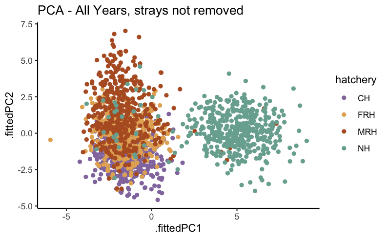

```r
library(broom)
# convert NAs back to 0, remove other columns
Sa1 <- Sa %>%
  select(-spawner_group, -sex, -year, -hatchery)
Sa1[is.na(Sa1)] <- 0

pca_1 <- Sa1 %>%
  select(where(is.numeric)) %>% # retain only numeric columns
  scale() %>% # scale data
  prcomp() # do PCA
pca_1gg <- pca_1 %>%
  augment(Sa) %>%
  ggplot(aes(.fittedPC1, .fittedPC2, color = hatchery)) +
  geom_point(size = 1.5) +
  theme_classic()+
  scale_color_manual(values = c(CH="#9379AD", FRH="#e4af62", MRH="#b65d2b", NH="#79ad9f"))+
  ggtitle("PCA - All Years, strays not removed")
pca_1gg
```

```r
ggsave(pca_1gg, "S4_PCAallpops.png", width = 20, height = 15, units = "cm", dpi = 800)
```

```
Error in path.expand(x) : invalid 'path' argument
```

### PCA - strays REMOVED

Remove ID columns from Sa1, then use prcomp() to run PCA, use augment function from broom to bind ids back on and then plot

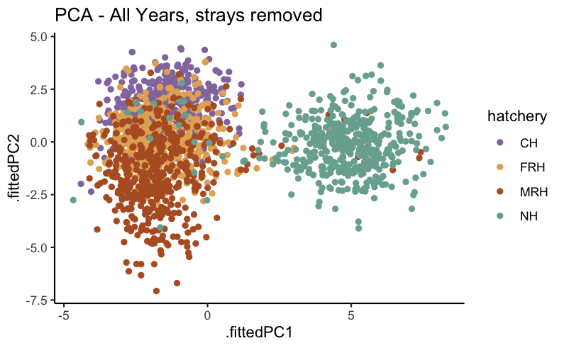

```r
library(broom)
# convert NAs back to 0, remove other columns
Sa1r <- Sar %>%
  select(-spawner_group, -sex, -year, -hatchery)
Sa1r[is.na(Sa1r)] <- 0

pca_1r <- Sa1r %>%
  select(where(is.numeric)) %>% # retain only numeric columns
  scale() %>% # scale data
  prcomp() # do PCA
pca_1rgg <- pca_1r %>%
  augment(Sar) %>%
  ggplot(aes(.fittedPC1, .fittedPC2, color = hatchery)) +
  geom_point(size = 1.5) +
  theme_classic()+
  scale_color_manual(values = c(CH="#9379AD", FRH="#e4af62", MRH="#b65d2b", NH="#79ad9f"))+
  ggtitle("PCA - All Years, strays removed")
pca_1rgg
```